[figure not shown]

Lagos Business School · Executive Education · Turning Data into Business Growth

# Unstructured data and the executive narrative

Day 4 · Publish it · Thursday 15 October 2026

Prof. Bongo Adi · Lagos Business School

## Today

Most of what your organisation knows about its customers is not in a database.

It is in call-centre notes, WhatsApp threads, branch survey free-text, app store reviews, and the box at the bottom of the form that nobody has ever read.

Until recently, reading all of it was economically impossible. That constraint has gone. The discipline required to use it has not.

## 4.1 · Text as data

09:15 — 10:15 · Five thousand reviews into five themes with volumes

## The classical pipeline, in four steps

**Tokenise → remove stop words → count → compare.**

To *tokenise* is to cut each piece of text into individual words, so that a review becomes a list rather than a sentence; each word is then called a **token**. *Stop words* are the words that appear in nearly every sentence and therefore distinguish nothing between them — “the”, “and”, “is”, “of”. What is left is a table you can count.

Run this before reaching for a language model. It costs nothing, it runs in seconds on a laptop, every step can be explained to an auditor line by line, and it answers the question outright more often than people expect.

## Frequency describes the corpus. Difference describes the problem.

Raw word counts are nearly useless. “Account”, “app” and “bank” top every list, in every bank, every time.

**Compare instead.** Words that appear in one-star reviews and not in five-star ones. Words that were rare last quarter and are common now. Words that appear on WhatsApp and never appear in the branch survey.

That one substitution — from counting one pile of text to comparing two — is most of the value in classical text analysis.

## Keep the negations

“not working” and “working” contain the same word.

The default stop-word list deletes **not**, **no** and **never** — which are precisely the words that carry a complaint.

*“not reversed” · “no response” · “never resolved”*

Count pairs of adjacent words rather than single words, and check what your stop-word list is throwing away before you trust the output.

## The word cloud is a picture, not a business case

It encodes quantity as **font size**, which humans compare badly, and position as **nothing at all**.

Long words look bigger at identical frequency. There is no scale, no axis and no order, so a reader cannot tell whether a word appeared 400 times or 40.

It is popular because it looks like insight and requires no argument.

**Send this instead:** five themes, their volumes, their trend, and one verbatim quote each.

That names what is wrong, says how much of it there is, says whether it is getting worse, and lets a reader hear a customer say it in their own words.

## Themes, sized and trended

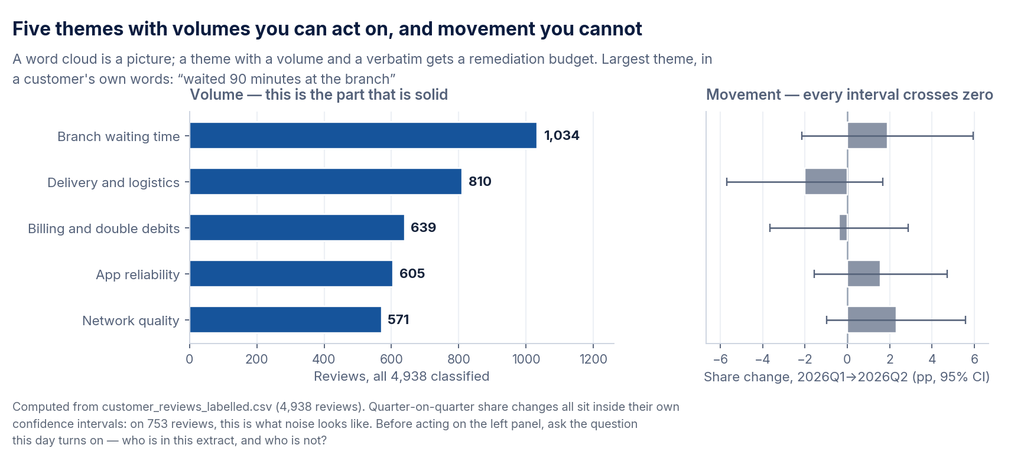

Left: five review themes as horizontal bars, branch waiting time largest at 1,034. Right: quarter-on-quarter share changes, each with a confidence interval that crosses zero.

## The multilingual problem is not optional here

About **one review in twelve** is in Nigerian Pidgin — and published benchmarks put accuracy on it below English.

> *“dem debit me two times, e never reverse”* *“network no dey work for my area”*

An English lexicon scores the first as neutral. So the classical pipeline **systematically under-counts complaints from the segment most likely to write in Pidgin** — which in most Nigerian consumer businesses is not a random segment.

A quantifiable bias with a commercial consequence. It is the strongest argument for the classifier in 4.2 — and a sentence worth putting in your method section.

## The part that matters more than any of it

```r
reviews |> summarise(n = n(), mean_stars = mean(star_rating),
                     detractors = mean(star_rating <= 2))
```

```
#> 4,938   3.52   0.260
```

Both numbers are correct. Both describe a population somebody already filtered.

Look at `customer_still_active`. The export had a `WHERE` clause on it, and the angriest customers — the ones who left — are missing.

## The most dangerous sentence in an analytics review

“Here is what the data says.”

The honest version is *“here is what the data that reached me says.”*

**Ask for the extraction query, not the extract.**

Ten seconds, one email, and never resented. No data quality rule catches this — the information about what was removed is not in what remains.

## Now in your sector · 4.1

Energy & extractives

HSE incident narratives, shift handover logs and maintenance notes as themes with volumes. 'Leak' near 'flange' is a bigram worth tracking.

Data: customer_reviews.csv (method); your own logs

Pensions & public sector

Contributor complaints in English and Pidgin: benefit delays, transfers, unremitted deductions, record updates.

Data: pension_complaints.csv

Financial services

Complaints and call-centre notes.

Data: customer_reviews.csv

Commercial & customer

App-store and social reviews; dealer feedback.

Data: customer_reviews.csv

## 4.2 · LLM classification at scale

10:45 — 11:45 · A classifier is a measurement instrument

## The new danger

It is now trivially easy to produce a confident-looking distribution of themes without ever finding out whether the classifier is any good.

Two hundred hand-labelled rows, or you do not have an error rate.

Forty minutes. It is the difference between “sentiment improved four points” being a finding and being noise.

## What it can and cannot be trusted to do

**Reliable at recognition.** Given a review and a fixed list of categories, deciding which one the review is about is close to what these models do natively — in English, in Pidgin, and in a sentence that switches between the two halfway through. Misspellings and missing punctuation do not trouble it.

**Unreliable where it needs knowledge it was not given.** It does not know your product names, your internal process boundaries, or that “the Tuesday run” means the replenishment cycle.

**Weakest where humans are weak — but it fails differently.** Sarcasm and mixed sentiment are genuinely hard, and two careful human labellers will disagree on them too. The difference is that a human says *“I am not sure about this one.”* The model does not.

## Four things that will bite you

**Cache.** You will re-run this. Without a cache you pay twice and get slightly different answers — then you cannot reproduce your own chart. Cache on a hash of the input text.

**Constrain the output.** Use a schema or an enum — a fixed list of permitted values — or you get `billing`, `Billing`, `billing issue` and `payment/billing` as four categories.

**Pin the dated version, temperature 0.** An alias points at different weights over time. Temperature is the setting that controls how much randomness enters the model’s choice of words; at zero it makes the most likely choice every time. The *cache* is the reproducibility mechanism, not a seed.

**Batch and retry.** Five thousand sequential calls take an hour and fail in the middle. Write results incrementally so an interrupted run resumes rather than restarts.

## Two hundred rows, labelled blind

1. **Draw a random sample** — two hundred rows, not twenty. At roughly 88% agreement, two hundred rows contain about twenty-four disagreements, which is enough to see a pattern in. Forty rows would give you about five.
2. **Label them by hand, blind.** Strip the model’s answer out of the file before anybody opens it. Shown the model’s answer first, a labeller agrees with it far more often than they otherwise would.
3. **Compare** — the overall agreement rate.
4. **Look at where the disagreements fall**, which is the step that repays the effort.

## Kappa, then the confusion matrix

**Cohen’s κ** corrects for chance agreement: how much of the agreement you observed is more than chance would have produced, as a share of the room there was for improvement.

Then read *where the 12% went.* Typical pattern here: `billing` and `app_reliability` get confused, because “the app debited me twice” is genuinely both.

That is not a model failure. It is a **taxonomy failure**, and it tells you your categories overlap.

## What goes in the paper

> *Themes were assigned by [model, dated version] at temperature 0 against a fixed seven-category taxonomy; labels were cached. A sample of 200 reviews, stratified by language, was hand-labelled blind. Agreement: **88%** on theme (κ ≈ 0.85), **94%** on sentiment. Disagreements concentrated on the billing / app-reliability boundary; those two are reported together. **8.6%** of the corpus is Nigerian Pidgin, where agreement is lower — too few rows in the sample to state a separate rate, and a stratified follow-up is planned.*

## Where it runs is a legal question

|  | Where the data goes | Use when |
| --- | --- | --- |
| **Hosted model** | Leaves the network, often the country | Not personal, not confidential |
| **Local model** | Nowhere | Customer records, HR text, anything under the NDPA |
| **In-region deployment** | Your tenancy | Procured and assessed |

For 4,938 anonymised course reviews, any of the three is fine.

For a bank’s actual call-centre notes, this is a **cross-border transfer of personal data** and it needs a lawful basis **before** anybody runs the script. Friday, in full.

## Now in your sector · 4.2

Energy & extractives

Classify work-order text into failure modes and validate 200 against a reliability engineer. Kappa is your inter-analyst agreement under another name.

Data: your own work orders; method from customer_reviews_labelled.csv

Pensions & public sector

Classify complaints into the regulator's own categories. Where the model runs is decided by the NDPA, so use a local model for real records.

Data: pension_complaints.csv

Financial services

AML alert narratives and complaint categories.

Data: customer_reviews_labelled.csv

Commercial & customer

Customer-care tickets at volume.

Data: customer_reviews_labelled.csv

## 4.3 · Dashboards that get used

11:45 — 12:45 · Design backwards from the decision

## The question that kills most dashboards

“What does the user do differently when this number is red?”

If the answer is *“they investigate”*, it is a starting point for work — legitimate, but name it and resource it as exploration, not as a management tool.

If the answer is *“they escalate to the depot manager and authorise expediting”*, you have a decision-support tool, and every design choice follows from that sentence.

## Design backwards, in five steps

1. **Name the decision.** *“Which SKU–depot lines get expedited this week?”*
2. **Name the user and the moment.** *“The supply planner, Tuesday morning, 20 minutes, before the replenishment run.”*
3. **Name the actions available.** Expedite · substitute · accept the stockout · delist. That is the decision space.
4. **Work out the minimum information that discriminates between those actions.** Usually four numbers: forecast demand, current cover, supplier lead time, margin at risk.
5. **Design the screen around those four.** Everything else is a drill-down, not a tile.

**More than about six top-level numbers** and the user has to decide what to look at before they can decide anything else. That second decision is why they stop opening it.

## One decision. Four numbers. An exception list.

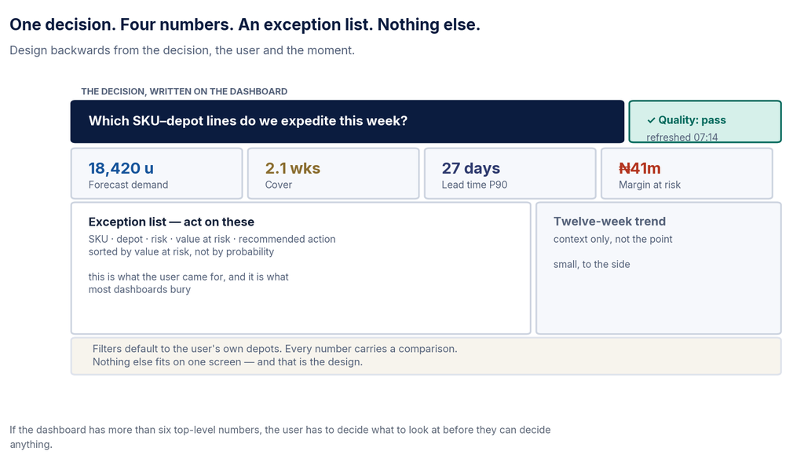

A dashboard wireframe: a navy header carrying the decision question, four KPI tiles, a large exception list, a small trend panel to the side, and a footer note.

## Where it gets delivered

Three routes, chosen by who reads it and how often rather than by preference.

- **A BI platform** when the audience already lives in it, needs row-level security, or needs to slice interactively. Build a star schema — facts and dimensions, as on Monday — rather than importing one wide flat table.
- **A generated dashboard** from the same source as your report when the audience is small and the content is more narrative than interactive. Free, version-controlled, and it regenerates with everything else.
- **A self-contained page** when somebody senior needs something clickable within the hour. It is the right answer far more often than the size of the tooling around BI platforms would suggest.

Whichever you choose: if it is not regenerated from the pipeline, it goes stale — and a stale dashboard is worse than no dashboard, because people trust it.

## Define measures once

Revenue, margin, availability, churn — defined **once, in the model**, against the fact table.

Not redefined inside each report.

The consequence when you get it wrong: two reports, both correct, both showing “availability”, disagreeing by two points, and a forty-minute meeting to discover one of them excludes delisted SKUs.

**Every organisation in this room has had that meeting.**

## Now in your sector · 4.3

Energy & extractives

The morning production meeting: one decision (where crews go today), four numbers (vs target, deferment, top down wells, HSE), one exception list.

Data: energy_production_daily.csv

Pensions & public sector

Supervision: which institutions or employers breached a threshold this month, and who acts.

Data: pension_remittances.csv

Financial services

Branch manager: PAR30, disbursement vs target, loans about to cross 30 days.

Data: bank_customers.csv

Commercial & customer

National sales manager: depot sell-out vs target and stockouts.

Data: fmcg_sell_out.csv

## 4.4 · One source, five outputs

13:45 — 14:45 · A document that regenerates itself

## The problem, which everybody has

An analyst produces the numbers. Somebody types a selection of them into a deck for the executive committee. Somebody else types a smaller selection into a memo for the audit committee. A third person, working from a slightly earlier version of the same extract, builds the dashboard.

Then a good question arrives late on the Thursday, one number is recomputed, and the corrected value is patched into the deck — because the deck is what is being presented on Friday — and not into the other two.

Four documents in circulation, at least two of them wrong, and nobody was careless.

## The single highest-value habit today

Never type a number into prose.

Not once. Not “just this one, it won’t change”.

Every number in every sentence is inline code that computes it. The moment one is typed, the document can disagree with itself — and it will, three months later, in front of somebody senior, when the typed figure is the only one on the page that did not move.

## One YAML block, five formats

| Output | Who for | Get this right |
| --- | --- | --- |
| HTML | The team, day to day | Self-contained, survives being emailed |
| PDF | The board pack | Page breaks, numbers, a real title page |
| **Word** | Legal, compliance, anyone tracking changes | **`reference-doc:`** — arrives in house style |
| reveal.js | Presenting | One idea per slide |
| Dashboard | The recurring decision | Session 4.3 |

The Word reference document removes the most common corporate objection to reproducible reporting, and almost nobody knows it exists.

## Parameterise, and twelve reports cost the same as one

```r
walk(depots, \(d) quarto::quarto_render(
  "report.qmd",
  execute_params = list(depot = d, quarter = "2026-Q1"),
  output_file = glue::glue("depot-{d}-2026Q1.html")))
```

This is where reproducible reporting stops being a tidiness virtue and becomes an obvious economic decision.

## The standard, as a test

Can a colleague clone your folder onto a clean machine and produce your PDF?

Three things break it: **absolute paths**, **packages installed interactively**, and **a manual step**. If it is not in the script, it does not exist.

## Now in your sector · 4.4

Energy & extractives

One parameterised asset report rendered for each asset, so every number is computed rather than typed.

Data: energy_production_daily.csv

Pensions & public sector

One report per supervised institution, state or LGA from a single template.

Data: pension_remittances.csv

Financial services

Branch packs.

Data: bank_customers.csv

Commercial & customer

Regional sales packs.

Data: fmcg_sell_out.csv

## 4.5 · The executive narrative

14:45 — 15:30 · The interruption is the design constraint

## Invert the structure. Always.

1. **The answer.** One sentence. The number and what to do.
2. **The confidence.** The interval and the assumption it rests on.
3. **The ask.** What you need from the person in the room.
4. **Everything else**, only if nobody interrupts.

That order feels wrong to anyone trained to build an argument. It is correct for anyone presenting to people with thirty other things on their list.

## Say the uncertainty out loud

**A.** *“Very confident. The model has been thoroughly validated.”*

Unfalsifiable. The first time it is wrong, it costs you every future number.

**B.** *“₦17.9m a year, central. My range is ₦8.1m–₦32.5m. The width is one assumption — how much stockout demand is lost rather than deferred. I’ve used a third. Pin it to ±5 points and the range narrows to about ₦15–21m. Two weeks of POS analysis would tell us.”*

**B** does five things: gives the decision-maker what they need, shows where the ignorance is, makes the next step obvious, is impossible to catch out, and **prices the cost of certainty.**

## Four hostile questions, four right answers

**“Where did this number come from?”** → Source, grain, period, exclusions, in one breath. *That is Tuesday’s work, and the attack ends there.*

**“Isn’t this just correlation?”** → Agree, precisely. *“Yes. To claim causation I would need the three-depot pilot, which is what I am asking for.”*

**“So what?”** → Decision, owner, money, date. One sentence.

**“That’s not what sales says.”** → *“Then one of us has a definition problem. Mine is X and it excludes Y. What is theirs?”*

## The memo and the meeting are different documents

|  | The memo | The meeting |
| --- | --- | --- |
| Read | Alone, quickly, possibly on a phone | Together, aloud, with interruption |
| Structure | Answer, confidence, ask, evidence | Answer, then respond to whatever they raise |
| Charts | One, embedded | One per point, large, no legends |
| Prepare | The document | The five questions |

One pattern worth trying: **send the memo 24 hours ahead and run the meeting as questions only.** It requires nerve, because the first thirty seconds are silent — and it produces better decisions, because the time is spent on the genuine disagreement rather than on exposition half the room did not need.

## Now in your sector · 4.5

Energy & extractives

To the MD: 'Uptime fell four points; two compressors explain 70% of it; approve the spares.' Engineering translated into money and a decision.

Data: energy pack

Pensions & public sector

To the Director-General or a Commissioner: the number, how sure, and the ask, in that order.

Data: pensions pack

Financial services

To the credit committee.

Data: bank_customers.csv

Commercial & customer

To the sales review.

Data: fmcg_sell_out.csv

## Lab 4 · The one-number brief

15:45 — 16:45

Two pages, rendered from your pipeline. Then defended in **ninety seconds** to a table you have not worked with.

Page 1: the number and the action · the interval and its driving assumption · the ask · what happens if we do nothing · one chart.

Page 2: data and grain · what was excluded and why · the assumption most likely to be wrong · how you will know if it worked · the command that regenerates it.

**Reviewer’s first act:** open the source and search it for digits outside code blocks.

## Close

Capstone checkpoint: **dashboard and memo exist**, both generated from the pipeline.

Tomorrow the panel asks, of every brief: *“how would you know if you were wrong?”*

If your answer tonight is “we would look at the trend”, read 5.2 and 5.3 before you arrive. The difference between a case that gets funded and one that gets deferred is almost always the answer to that single question.